# dfp_excl7_09-17

**Composition du dossier**

2 répertoires :

- **`/scripts`** : contient 6 scripts au format .R.
  - 2 pour le data management : **`_setup`** et **`_fonctions`**.
  - 4 pour la sortie des résultats : `tab_*` et `fig_*`
- **`/output`** : répertoire de stockage automatique des tableaux et figures (voir détails)

La base **`dfp_excl7_09-17.RData`**

# 1 Data management :

## 1.1 Script **`_fonctions`**

**Note**

J’ai écris des fonctions mais pas encore la documentation qui va avec. Il s’agit d’une première version, la plupart sont encore peu flexibles et peu explicites du fait de cette absence, et évolueront avec le temps. La documentation est prévu à moyen terme, en attendant il sera nécessaire de se référer à **`_fonctions`** directement pour en connaitre les détails et notamment les valeurs prises par défaut, qui sont souvent absentes des scripts.

L’exécution de **`_fonctions`** est demandée au début de **`_setup`**.

```r
source("scripts/_fonctions.R")
```

Il n’est donc pas nécessaire d’exécuter ce script individuellement (on peut voir **`_fonctions`** comme un fichier de stockage).

## 1.2 Script **`_setup`**

**Globalement**

L’exécution de **`_setup`** aboutit à la création d’une liste nommée `opts` (pour “options”).

Cette liste regroupe des paramètres sujets à modification dans un même objet, et permet *in fine* d’automatiser les changements dans tous les scripts en aval, sans avoir à modifier les scripts en question (e.g. choix de la période de suivi, variables à inclure dans les modèles, mais aussi des détails comme les séparateurs ou les bornes de l’IC).

Elle est utilisée comme référence pour tous les autres scripts, même **`_fonctions`**.

`opts` est en fait une compilation de 6 listes, toutes précédées du préfixe `opts_`. Cette compilation a lieu en plusieurs temps.

**Pourquoi faire plusieurs listes intermédiaires et pas une seule directement ?**

Certaines listes doivent parfois se référer à des élements déjà stockées dans des listes précédentes, c’est pourquoi tout ne peut pas être assigné d’un coup dans un même objet (une liste ne peut pas s’autoréférencer). Leur ordre dans le script est régit par cette dépendance.

On peut subdiviser **`_setup`** en 4 étapes successives :

1. Création de la liste `opts` et de ses premières sublists
2. Préparation de la base **`dfp_excl7_09-17.RData`** avant recodage
3. Recodage de la base
4. Incrémentation de la dernière sublist à `opts`

**Note sur les packages**

Tous les packages additionels chargés dans le script sont utilisés et doivent être installés (normalement RStudio détecte lesquels sont absents et propose de les installer).

D’autres packages sont utilisés mais pas chargés car non utilisés plus de 3 fois dans l’ensemble des scripts. Ils sont appelés directement dans le code avec le suffixe `::` suivi de la fonction (e.g. `knitr::kable()`).

### 1.2.1 Étape 1

#### 1er temps : création d’une liste `opts`

Ceci via la fonction `opts_set()`, dont voici les valeurs prises par défaut (détails dans **`_fonctions`**).

```r
# dans _fonctions

opts_set <- \(suivi_an = 1, suivi_jr = suivi_an * 365,
              fdr = FALSE, fdr_start = 2014,
              fdr_suffix = "_fdr", output_suffix = "",
              sex_m = "Men", sex_f = "Women",
              yes = "Yes", no = "No", na = "Missing data",
              int_sep = ":", out_sep = ";", ci_sep = ";",
              ci_lim = "[", ci_level = "95", ci_term = "%CI",
              p_format = ~ style_pvalue(.x, digits = 3),
              font_alpha = "Bahnschrift", font_num = "calibri",
              color_ref = "#999999", color_back_light = "white",
              color_back_dark = "#292929", color_front_light = "#e1f6ff",
              color_front_dark = "#0099CC", sep_gap = FALSE)
```

```r
# dans _setup

opts_set(suivi_an = 1, fdr = FALSE)
```

L’exécution de cette fonction aboutit à la création d’un objet de classe liste nommé `opts` et contenant une première sublist nommée `opts$set`.

**Important**

Le suivi de 1 an et la non prise en compte des facteurs de risques sont les valeurs prises par défaut, mais je les ai explicitées par principe du fait que ce sont les paramètres les plus importants, qui définissent la population d’étude (avec `fdr_start` également).

La création des autres listes ne se fait pas via des fonctions nommées `opts_*()*` mais repose sur le même principe que `opts_set()` : une fonction qui produite une liste.

Chaque liste produite sera assignée à un objet nommé `opts_*` et sera *in fine* incrémentée à la liste parent `opts`, qui pour rappel contient déjà la sublist `opts$set`.

La sublist `opts$set` a par défaut la configuration suivante :

```r
opts$set
```

```
$suivi_an
[1] 1

$suivi_jr
[1] 365

$fdr
[1] FALSE

$fdr_start
[1] 2014

$fdr_suffix
[1] "_fdr"

$output_suffix
[1] ""

$p_format
~style_pvalue(.x, digits = 3)
<environment: 0x00000270036b99f8>

$lab
$lab$sex_m
[1] "Men"

$lab$sex_f
[1] "Women"

$lab$yes
[1] "Yes"

$lab$no
[1] "No"

$lab$na
[1] "Missing data"


$sep
```

[output cut: 32 more lines]

```
$color
$color$ref
[1] "#999999"

$color$back_light
[1] "white"

$color$back_dark
[1] "#292929"

$color$front_light
[1] "#e1f6ff"

$color$front_dark
[1] "#0099CC"
```

#### 2e temps : création des autres sublists `opts_*` et première incrémentation

Les sublistes sont les suivantes, dans l’ordre :

- `opts_vargrp` : variables groupées (`fdr` et `major complications`, elles apparaitront automatiquement regroupées dans les tableaux) + objets utilisés pour les modéles multivariés (`surv` et `strata`)
- `opts_abb` : abbréviations, communes aux tableaux et figures
- `opts_tab` : caractéristiques propres aux tableaux (“`base`” désigne les variables incluses dans `tab_1` et `tab_inter`)
- `opts_fig` : caractérisiques propres aux figures

Ses sublists sont ensuites incrémentées à `opts` via la fonction `append()`.

**Note**

Cette première partie du script regroupe déjà la majorité des paramètres qui composeront `opts`. Lorsque des modifications quelconques doivent être apportées (e.g. ajout/retrait d’une variable dans un modèle, d’une note de bas de tableau), c’est normalement ici faudrait le faire.

### 1.2.2 Étape 2

- 1er temps : création des variables `rec` et `tt_rec` (“time to rec”) avec censure à droite (suffixe “`_csr`”) pour la fonction de survie, puis cadrage de la base selon les critères de sélection
- 2e temps : reconversion de la base au format long (par épisode), plus simple à manipuler par la suite

La base ainsi traitée, nommée `d`, contient tous les cas incidents (récidivants ou non) + les cas récidivants. Elle sera splitée sur l’épisode par la suite.

### 1.2.3 Étape 3

Consiste principalement au recodage de variables et à certains ajouts.

Un exemple parmi bien d’autres d’une fonction qui n’est peut-être pas assez explicite de prime abord (détails dans **`_fonctions`**) :

La fonction `binr()` permet de créer simplement des variables binaires, ou de binariser des variables catégorielles existantes, en fonction de la valeur d’autres variables ou groupes de variables de n’importe quel type.

```r
d %>%
  binr(tropo, bio_tropo_dose >= bio_tropo_seuil * 2) %>%
  binr(fdr, opts_vargrp$fdr[-1], auto_bin = TRUE)
```

> 1. “Dans le dataset `d`, créé-moi une variable binaire nommée `tropo` qui prendra la valeur”oui” si la tropo est supérieure à 2x la norme, et la valeur “non” dans le cas contraire.”
> 2. “Créé-moi aussi une variable binaire nommée `fdr` qui prendra la valeur”oui” si au moins une des variables regroupées sous `fdr` prend la valeur “oui”, et la valeur “non” dans le cas contraire.”

Il y aurait moyen d’appliquer la fonction à toutes les variables en une seule fois mais je n’ai pas pris le temps de coder ça. Il y a donc quelques répétitions…

**Note**

Les objets `.ecg` et `.type`, utilisés pour coder la variable “Symptômes” (`d$sympt_type`), n’ont pas d’autre utilité que d’éviter les répétitions futures dans le code.

A noter que de manière générale les objets dont le nom débute par un `.` n’apparaissent pas dans l’environnement et ne sont donc pas supprimés quand bien même on leur applique un `rm()` (j’ai découvert ça fortuitement la semaine dernière, je partage au cas-où).

### 1.2.4 Étape 4

Les fonctions majeures de `set_data()` sont :

1. Configuration de la base “avec fdr”
2. Split de la base `d` sur la variable épisode : `d.1` contient tous les cas incidents (rec 0 ou 1) et `d.2` les cas récidivants, sur la durée de suivi choisie (rec 1) (à vrai dire d.2 n’est pas utilisée)
3. création d’une dernière sublist contenant les modèles utilisés pour le `tab_2` (raison pour laquelle elle ne peut être ajoutée qu’après traitement de la base)
4. incrémentation de cette sublist à `opts`

La liste `opts` est enfin complète et par défaut composée comme suit :

```r
opts
```

```
$set
$set$suivi_an
[1] 1

$set$suivi_jr
[1] 365

$set$fdr
[1] FALSE

$set$fdr_start
[1] 2014

$set$fdr_suffix
[1] "_fdr"

$set$output_suffix
[1] ""

$set$p_format
~style_pvalue(.x, digits = 3)
<environment: 0x0000027001d4c518>

$set$lab
$set$lab$sex_m
[1] "Men"

$set$lab$sex_f
[1] "Women"

$set$lab$yes
[1] "Yes"

$set$lab$no
[1] "No"

$set$lab$na
[1] "Missing data"


```

[output cut: 166 more lines]

```

$abb$IR
[1] "IR: incidence rate"

$abb$BMI
[1] "BMI: body mass index"

$abb$ACS
[1] "ACS: acute coronary syndrome"

$abb$NSTEMI
[1] "NSTEMI: non-ST-elevation myocardial infarction"

$abb$STEMI
[1] "STEMI: ST-elevation myocardial infarction"
```

**Note**

`set_data()` est une fonction, et pourtant elle ne figure pas dans le script **`_fonctions`**.

C’est effectivement une exception car il ne s’agit pas d’une fonction anonyme (elle doit utiliser certaines variables issues de la base). En revanche la base elle-même peut être renommée sans que le reste ne soit affecté.

Les sublists (ainsi que la base native `dfp2`) ne sont plus utiles et peuvent être supprimées pour éviter toute confusion avec `opts`.

```r
rm(dfp2); rm(list = ls()[str_starts(ls(), "opts_")])
```

Si cette fonction reste activée, l’environnement ne doit finalement contenir que 4 objets : `d`, `d.1`, `d.2` et `opts`.

### 1.2.5 Application

Les valeurs par défaut de `opts$set` définissant la population d’étude sont les suivants :

```r
opts_set(suivi_an = 1, fdr = FALSE)
```

Avec ces valeurs, l’exécution du script permet via la fonction `set_data()` de faire les vérifications suivantes :

```
[[1]]


|.                   |.           |
|:-------------------|:-----------|
|follow-up           |1 an(s)     |
|inclusion index     |2009 à 2016 |
|date index max      |2016        |
|date recidive max   |2017        |
|age index max       |73.999      |
|age recidive max    |74.987      |
|n study pop         |15318       |
|n rec sur follow-up |1022        |

[[2]]
multivariable model:
930 events included on 14498 total observations,
820 (5.35%) observations were deleted for missing.
```

**Important**

Les chiffres obtenus avec les paramètres par défaut doivent être identiques à ceux présentés ci-dessus. Si ce n’est pas le cas, il y a un problème.

**suivi 1 an sans fdr (par défaut)**

```r
opts_set(suivi_an = 1, fdr = FALSE)
```

```
[[1]]


|.                   |.           |
|:-------------------|:-----------|
|follow-up           |1 an(s)     |
|inclusion index     |2009 à 2016 |
|date index max      |2016        |
|date recidive max   |2017        |
|age index max       |73.999      |
|age recidive max    |74.987      |
|n study pop         |15318       |
|n rec sur follow-up |1022        |

[[2]]
multivariable model:
930 events included on 14498 total observations,
820 (5.35%) observations were deleted for missing.
```

**suivi 1 an avec fdr**

```r
opts_set(suivi_an = 1, fdr = TRUE)
```

```
[[1]]


|.                   |.           |
|:-------------------|:-----------|
|follow-up           |1 an(s)     |
|inclusion index     |2014 à 2016 |
|date index max      |2016        |
|date recidive max   |2017        |
|age index max       |73.999      |
|age recidive max    |74.987      |
|n study pop         |5914        |
|n rec sur follow-up |328         |

[[2]]
multivariable model:
295 events included on 5558 total observations,
356 (6.02%) observations were deleted for missing.
```

**suivi 5 ans**

```r
opts_set(suivi_an = 5, fdr = FALSE)
```

```
[[1]]


|.                   |.           |
|:-------------------|:-----------|
|follow-up           |5 an(s)     |
|inclusion index     |2009 à 2012 |
|date index max      |2012        |
|date recidive max   |2017        |
|age index max       |73.996      |
|age recidive max    |74.93       |
|n study pop         |7478        |
|n rec sur follow-up |1027        |

[[2]]
multivariable model:
958 events included on 7070 total observations,
408 (5.46%) observations were deleted for missing.
```

Si on applique ça aux résultats, en modifiant certaines paramètres contenus dans `opts` puis en exécutant le script `tab_2` par exemple :

**Par défaut**

```r
opts_set(suivi_an = 1, fdr = FALSE)

source("scripts/_setup.R")
```

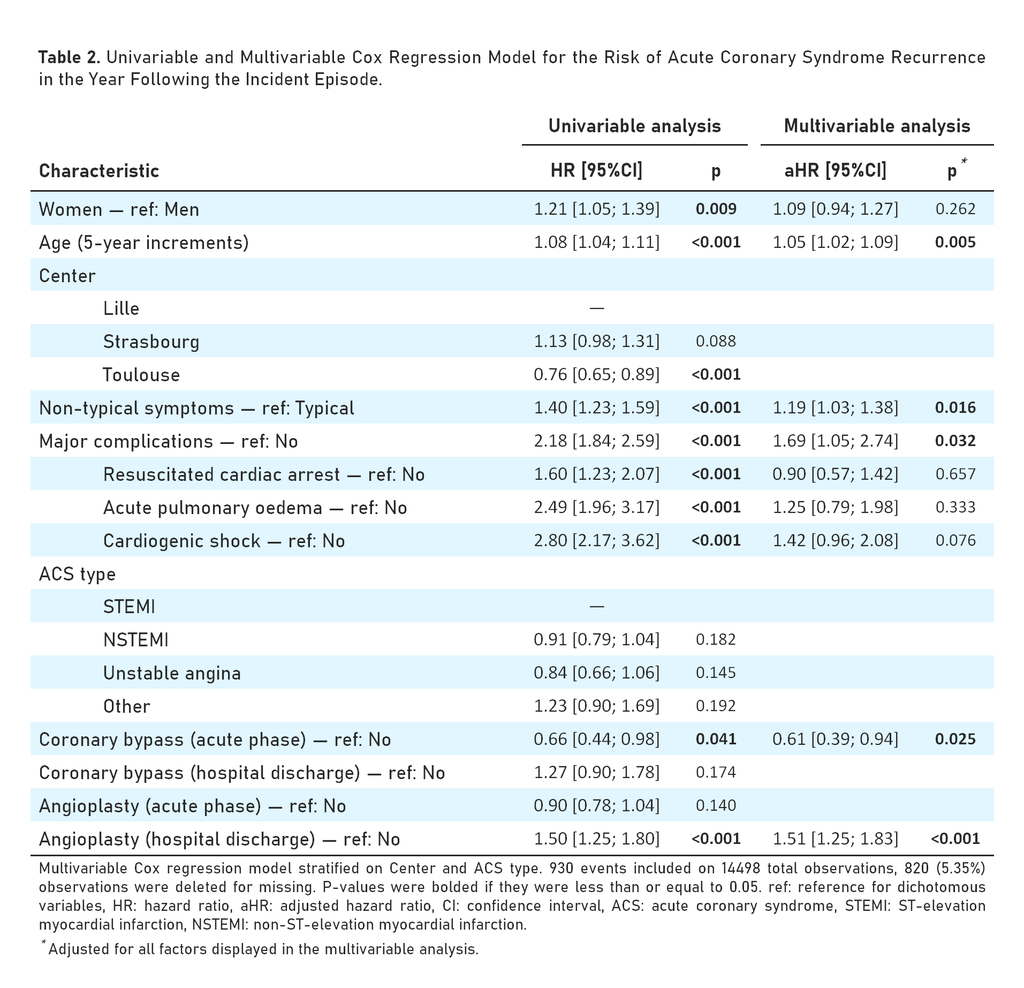

**Avec changements**

```r
opts_set(suivi_an = 1, fdr = TRUE,
         sex_m = "Male", sex_f = "Female", ci_lim = "(")

source("scripts/_setup.R")
```

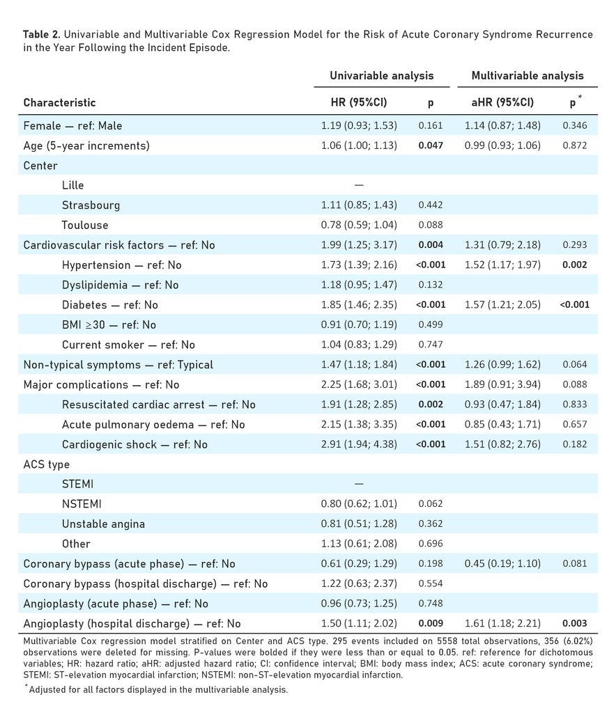

Les modifications ont pris effet sans nécessiter une autre action que la modification de la fonction `opts$set()`et l’exécution du script du tableau correspondant.

Cet exemple concerne `opts$set()` mais le principe est le même pour les autres sublists : les injections de `opts` dans les scripts en aval vont permettre d’appliquer automatiquement les changements induits par l’utilisateur dans `opts_*`, *sans qu’il y ait besoin de modifier manuellement les scripts pour lesquels ces changements s’appliquent.*

**Le principe de base**

**est donc qu’il n’y a pas un script (ou un objet) pour chaque configuration différente des données (e.g. un pour `tableau 2` sans fdr, un autre pour `tableau 2` avec fdr), mais bien un seul et même script (ou objet) pour `tableau 1`, `tableau 2`, `figure 1` etc., qui sortira en tenant compte des paramètres définis dans `_setup` (notamment la partie 1).**

Une fois **`_setup`** exécuté, il ne reste plus qu’à sortir les résultats.

# 2 Sortie des résultats

**4 scripts**

- **`tab_1`** : descriptif de la population d’étude
- **`tab_2`** : analyse uni/multivariée
- **`tab_inter`** : tableau pour interaction sexe x episode *(en cours)*
- **`fig_1`** : courbe d’incidence cumulée

## 2.1 Structure commune

Tous les scripts sont structurés de la manière suivante :

```r
source("scripts/_setup.R")

# contenu #

output("[nom de l'objet à sortir]")
```

`source()` permet la connexion à **`_setup`** pour reset l’environnement de façon systématique à chaque exécution et ceci sans même que **`_setup`** ne soit ouvert (du moment que le working directory est bien celui défini dans **`_setup`**).

#### La fonction `output()`

`output()` convertit l’objet aux formats *`.html`* et *`.png`* et stocke automatiquement ces fichiers dans le répertoire **`/output`**.

Les fichiers sont nommés à partir du nom donné à l’objet dans le script suivi d’un suffixe (ou pas)

- Les tableaux prennent comme suffixe “`_fdr`” si `fdr = TRUE` (aucun suffixe par défaut)
- Les figures prennent toujours comme suffixe la durée de suivi demandée en années sous la forme “`_[durée]a`”

Chaque exécution s’accompagne d’un message indiquant le chemin de sortie du fichier avec le nom qui lui est donné.

Exemples :

```r
# tab_2 : 1 an sans fdr (par défaut)
opts_set(suivi_an = 1, fdr = FALSE)
#----------------------------------
output(tab_2)

# ~/output/tab_2.png"
```

```r
# tab_2 : 1 an avec fdr
opts_set(suivi_an = 1, fdr = TRUE)
#---------------------------------
output(tab_2)

# ~/output/tab_2_fdr.png"
```

```r
# fig_1 : 1 an sans fdr (par défaut)
opts_set(suivi_an = 1, fdr = FALSE)
#----------------------------------
output(fig_1)

# ~/output/fig_1_1a.png"
```

```r
# fig_1 : 5 ans sans fdr
opts_set(suivi_an = 5, fdr = FALSE)
#----------------------------------
output(fig_1)

# ~/output/fig_1_5a.png"
```

**Note**

Chaque fichier créé à l’exécution de `output()` **écrase** le fichier de même nom déjà existant, il ne peut donc pas y avoir de doublons dans le répertoire **`/output`**.

Le `.png` est une capture du `.html`, les marges sont définies automatiquement en fonction des dimension de l’objet. Il n’y a aucun traitement à faire une fois que celui-ci est sorti. De façon générale il n’y a normalement pas besoin d’ajouter ou modifier manuellement du contenu dans le dossier **`/output`**, tout étant déjà automatisé.

Le chemin de destination ainsi que le nom donné aux fichiers est modifiable via `output()` (détails dans **`_fonctions`**).

Le `.html` s’ouvre dans un nouvel onglet à chaque exécution, ce qui est pratique pour comparer facilement la nouvelle version avec l’ancienne lorsqu’on travaille dessus (avec le navigateur sur une moitié de l’écran et le script sur l’autre par exemple).

## 2.2 Tableaux

La structure du contenu encadré par `source()` et `output()` est la même pour chaque tableau (à l’exception de `tab_inter` qui est inachevé)

- Largeur du tableau et titre : auraient pu être intégrés à `opts` comme le reste mais avec une subtilité en plus, je ne m’y suis donc pas consacré
- Création d’un premier tableau au format `gt_summary` : prend toujours le suffixe “`_.gts`”
- Conversion du tableau au format “`gt`”
- La fonction `tab_data()` : sert à générer les dataframes contenant les données bruts des tableaux (utile seulement pour programmer, désactivée par défaut)

**Pourquoi 2 formats de tableaux pour finalement n’en sortir qu’un seul ?**

`gt_summary` sert à produire les stats tout en sortant les résultats sous forme d’un tableau. La fonction `tab_format()` crée un formatage de base (détails dans **`_fonctions`**). Après ça c’est plus pratique de passer au format `gt` pour enrichir (titres, annotations, style etc.), qui est le “vrai” format tableau, plus flexible.

#### Tableaux bruts sortis au 27/04/23

**tab_1**

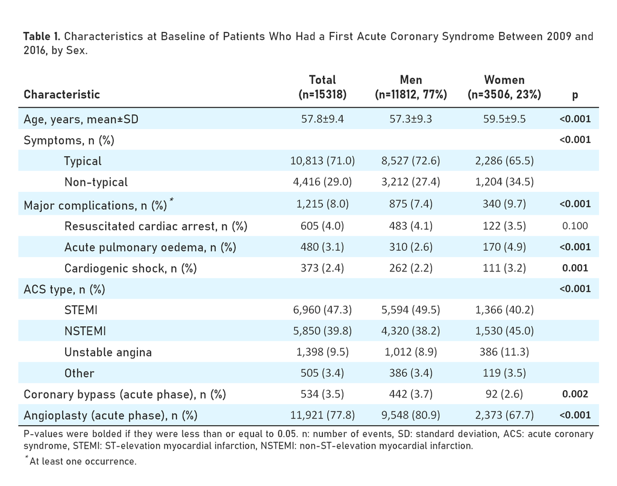

**tab_1_fdr**

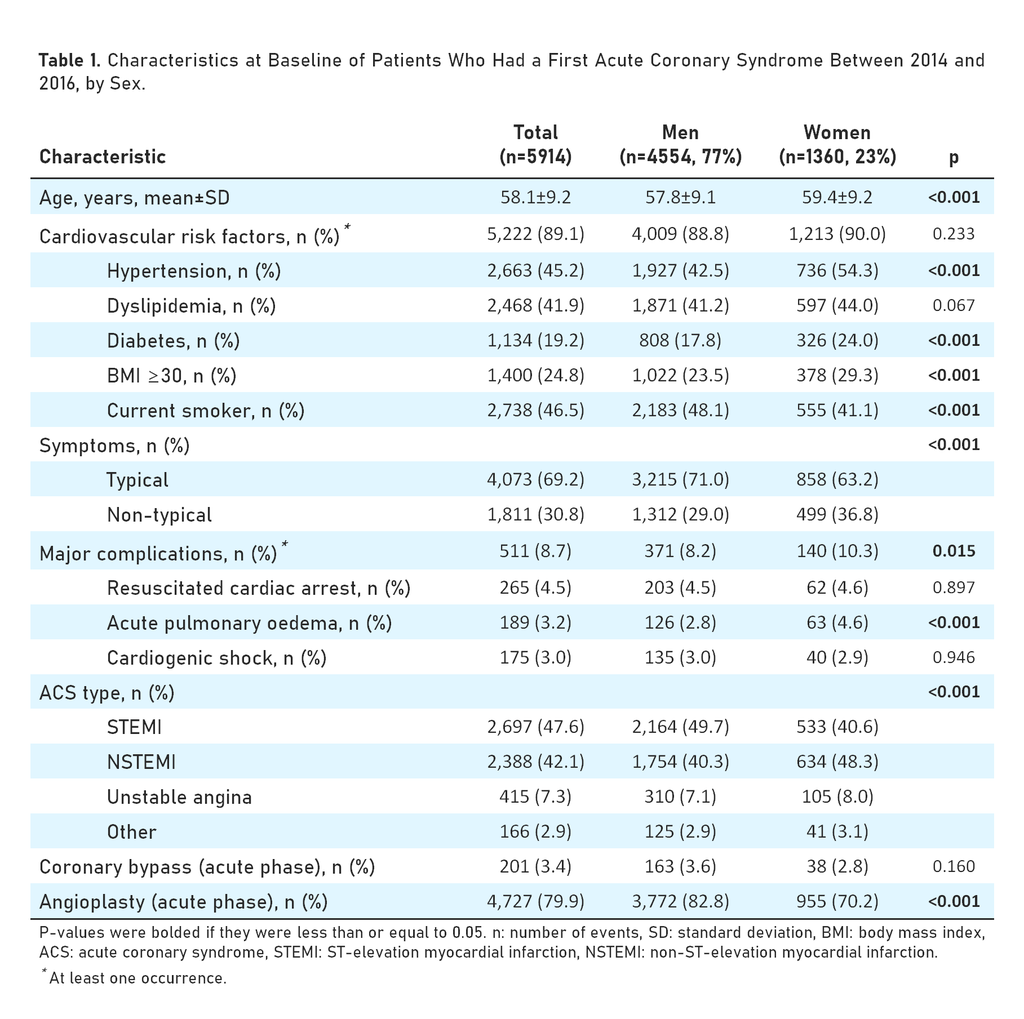

**tab_2**

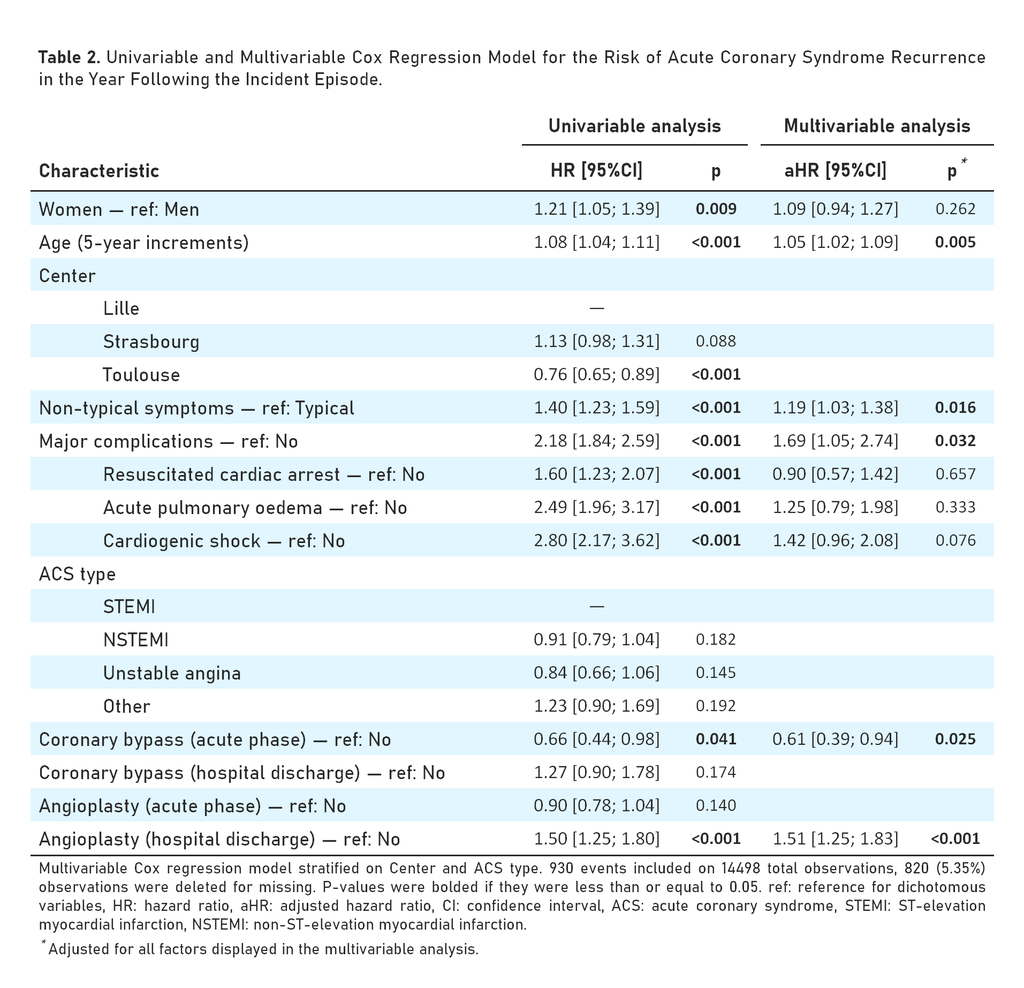

**tab_2_fdr**

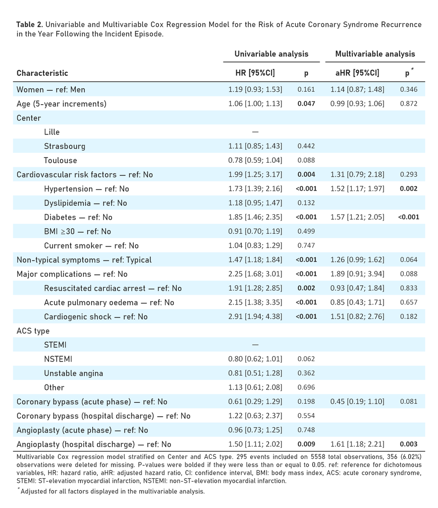

**tab_inter**

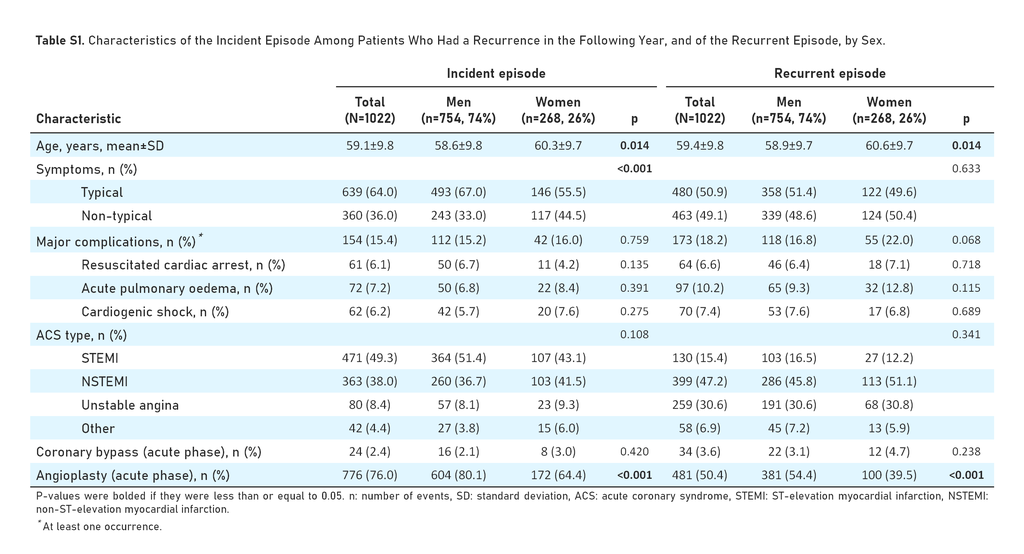

**tab_inter_fdr**

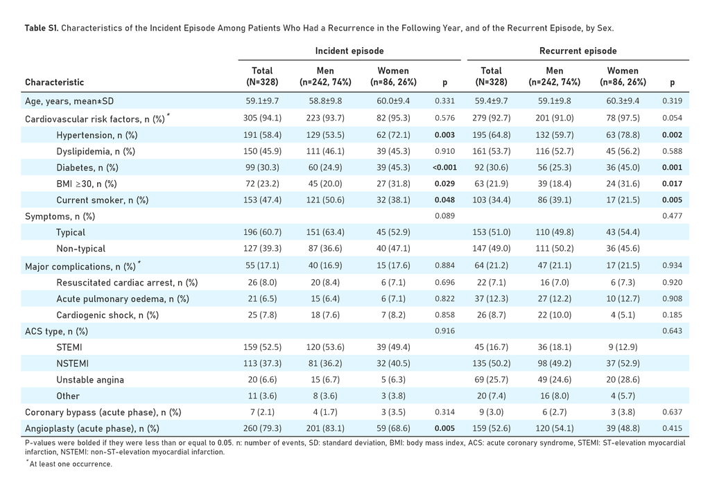

## 2.3 Figures

5 objets, dans l’ordre :

- `fig_1_test` : un dataframe du modèle univarié, duquel certaines valeurs sont extraites et intégrées au plot (HR et p value)
- `fig_1_plot` : fonction d’incidence cumulée, servant de base au plot
- `fig_1_tab` : données servant de base au tableau en bas à droite du plot
- `fig_1_tab.plot` : conversion du `fig_1_tab` permettant son intégration au plot
- `fig_1` : le plot sous sa forme finale

#### Figures brutes sorties au 27/04/23

**fig_1_1a**

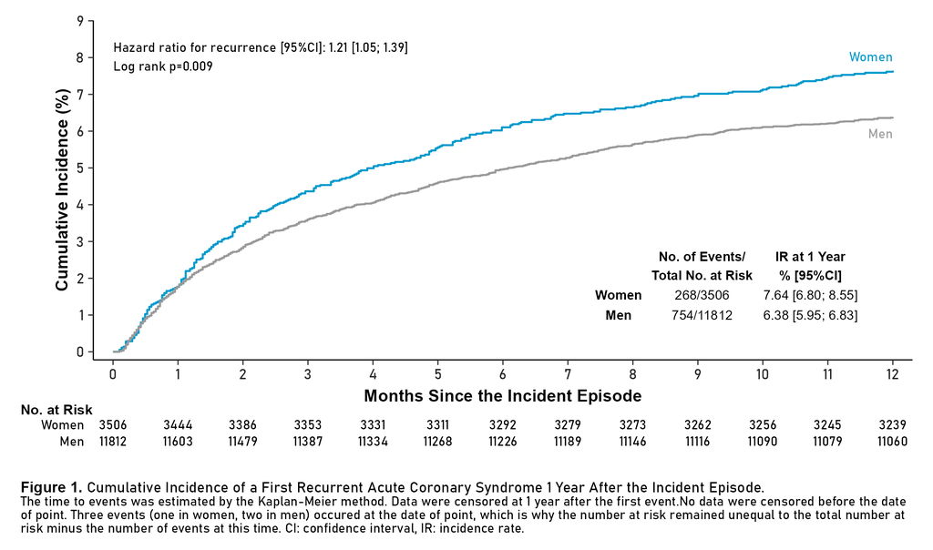

**fig_1_5a**

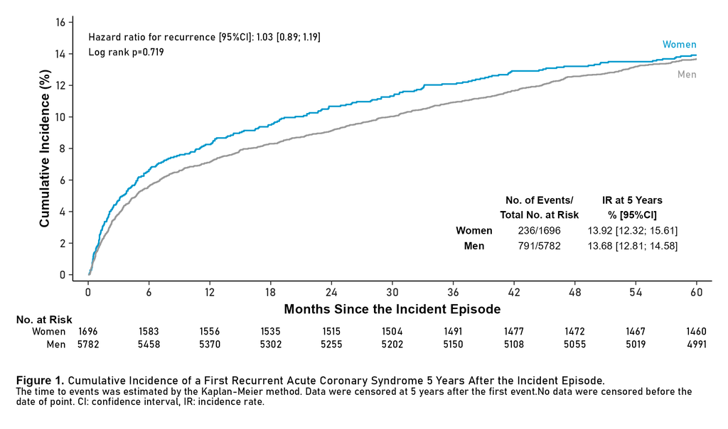